# Airline Customer Satisfaction - Group 17

### 2.2.3 Association Between Numerical and Categorical Variable

Now, we will analyze the association between numerical and categorical variables. We will use boxplots to visualize the distribution of numerical variables across different categories.

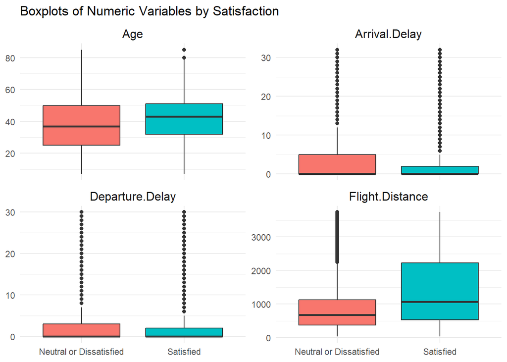

```r
data_subset <- data %>%
  select(Satisfaction, Age, Flight.Distance, Departure.Delay,
         Arrival.Delay)

# Convert to long format for faceting
data_long <- pivot_longer(data_subset, -Satisfaction, names_to = "Variable", values_to = "Value")

# Plot boxplots with facets
ggplot(data_long, aes(x = Satisfaction, y = Value, fill = Satisfaction)) +
  geom_boxplot() +
  facet_wrap(~ Variable, scales = "free_y") +
  theme_minimal() +
  labs(title = "Boxplots of Numeric Variables by Satisfaction",
       x = NULL, y = NULL) +
  theme(
    strip.text = element_text(size = 12),
    legend.position = "none"
  )
```

The boxplots compare numeric variables (Age, Arrival Delay, Departure Delay, and Flight Distance) by satisfaction levels (Neutral or Dissatisfied vs. Satisfied). Satisfied customers tend to have higher ages and longer flight distances, as indicated by the higher medians and broader distributions for these groups. Conversely, Arrival and Departure Delays show minimal differences between satisfaction groups, with both distributions being highly skewed and overlapping significantly. This suggests that delays may not strongly influence satisfaction compared to age and flight distance.

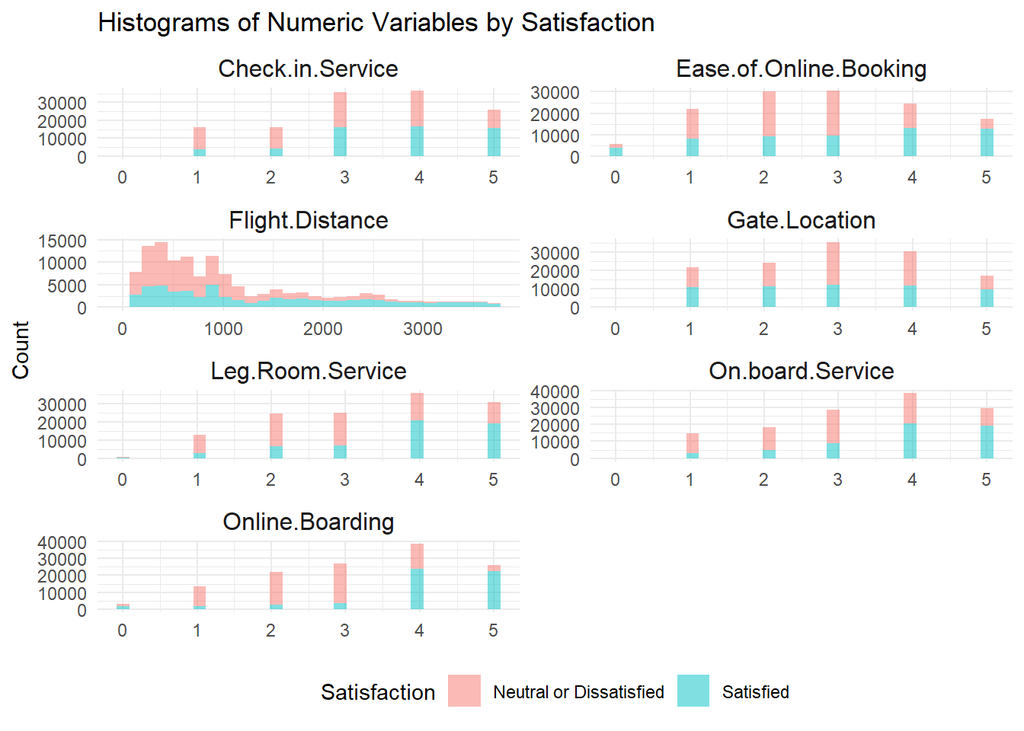

```r
data_subset <- data %>%
  select(Satisfaction, Ease.of.Online.Booking, Check.in.Service, Online.Boarding,
         Gate.Location, On.board.Service, Leg.Room.Service, Flight.Distance)

# Convert to long format
data_long <- pivot_longer(data_subset, -Satisfaction, names_to = "Variable", values_to = "Value")

# Create faceted histogram
ggplot(data_long, aes(x = Value, fill = Satisfaction)) +
  geom_histogram(position = "stack", alpha = 0.5, bins = 30) +
  facet_wrap(~ Variable, scales = "free", ncol = 2) +
  theme_minimal() +
  labs(title = "Histograms of Numeric Variables by Satisfaction",
       x = NULL, y = "Count") +
  theme(
    strip.text = element_text(size = 12),
    legend.position = "bottom"
  )
```